# Loading and preprocessing the data

## Loading and preprocessing the data

- Loading the Data

```r
data <- read.csv("activity.csv", header = T )
```

- Preprocessing the data

```r
dataclean <- data[which(data$steps!= "NA"), ]
## correct the date formate
dataclean$date <- as.Date(dataclean$date, "%Y-%m-%d")
```

## What is mean total number of steps taken per day?

- Histogram of the total number of steps taken each day

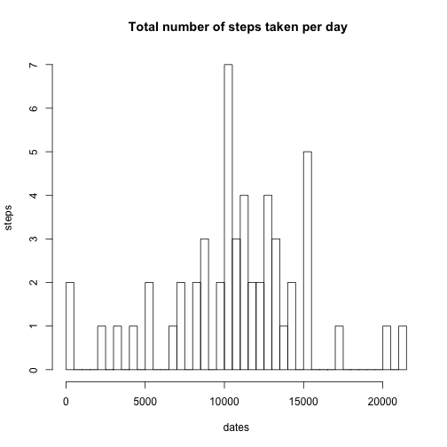

```r
## spliting the data by steps and dates, caculate the sum of steps
splitStepbyDate <-split(dataclean$steps, dataclean$date)
StepSum <- as.data.frame(sapply(splitStepbyDate, sum))
names(StepSum) <- c("steps")
## making the graph
hist(StepSum$steps, breaks = nrow(StepSum),
     main =" Total number of steps taken per day",
     xlab ="dates", ylab = "steps")
```

- The *mean* and *median* total number of steps taken per day

```r
mean(StepSum$steps)
```

```
## [1] 10766.19
```

```r
median(StepSum$steps)
```

```
## [1] 10765
```

## What is the average daily activity pattern?

- Make a time series plot of the 5-minute interval and the average number of steps taken, averaged across all days

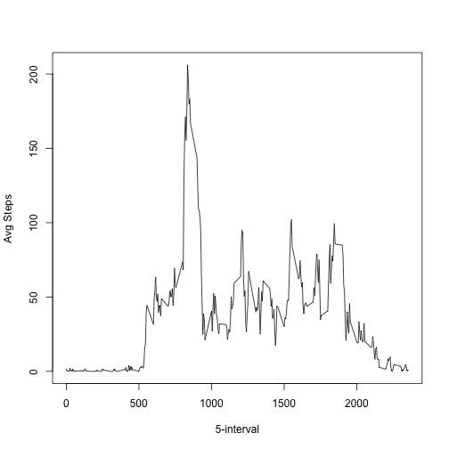

```r
library(plyr)
databyStepAvg <- ddply(dataclean, .(interval), summarize, steps = mean(steps))
plot(databyStepAvg$interval, databyStepAvg$steps, type = "l",xlab = "5-interval", ylab = "Avg Steps")
```

- Which 5-minute interval, on average across all the days in the dataset, contains the maximum number of steps?

```r
databyStepAvg$interval[which.max(databyStepAvg$steps)]
```

```
## [1] 835
```

## Imputing missing values

- Calculate and report the total number of missing values in the dataset

```r
sum(is.na(data))
```

```
## [1] 2304
```

- Devise a strategy for filling in all of the missing values in the dataset. The strategy does not need to be sophisticated. For example, you could use the mean/median for that day, or the mean for that 5-minute interval, etc.

  I will use the mean for that 5-minute interval.
- Create a new dataset that is equal to the original dataset but with the missing data filled in.

```r
## changing colnames from steps to intervalMean
colnames(databyStepAvg) [2] <- "intervalMean"
library(plyr)
## Merge the data by using interval as indicator
combined <- arrange(join(data, databyStepAvg),interval)
## Replacing the NA value by the mean of 5-minute interval
combined$steps[is.na(combined$steps)] <- combined$intervalMean[is.na(combined$steps)]
```

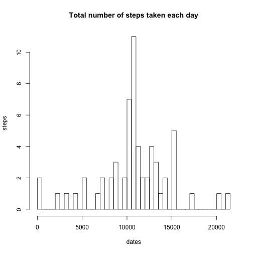

```r
Newcombined <- ddply(combined,.(date),summarise, steps = sum(steps))
hist(Newcombined$steps,
     breaks = nrow(Newcombined),
     main = "Total number of steps taken each day",
     xlab = "dates", ylab = "steps")
```

1. Mean and Meddian

```r
mean(Newcombined$steps)
```

```
## [1] 10766.19
```

```r
median(Newcombined$steps)
```

```
## [1] 10766.19
```

## Are there differences in activity patterns between weekdays and weekends?

- Create a new factor variable in the dataset with two levels – “weekday” and “weekend” indicating whether a given date is a weekday or weekend day.

```r
## setting weekdays type to current date data
weekdays <- weekdays(as.Date(combined$date))
## adding new column day
CombinedwithDays <- transform(combined, day = weekdays)
## adding new colum type
CombinedwithDays$type <- ifelse(CombinedwithDays$day %in% c("Saturday", "Sunday"), "weekend", "weekday")
## new dataframe with mean of steps
NewCombinedwithDays <- ddply(CombinedwithDays, .(interval, type), summarise, steps = mean(steps))
```

- Make a panel plot containing a time series plot of the 5-minute interval (x-axis) and the average number of steps taken, averaged across all weekday days or weekend days (y-axis).

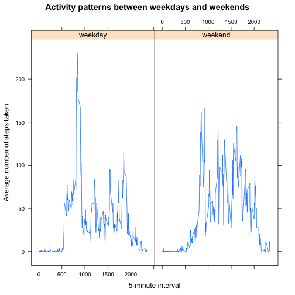

```r
library(lattice)
par(mfrow = c(1,2))
xyplot(steps ~ interval| type, data = NewCombinedwithDays,
       type = "l",
       main = "Activity patterns between weekdays and weekends",
       xlab = "5-minute interval", ylab = "Average number of steps taken")
```